# Identificación de genes diferencialmente expresados

# librerias y datos de partida

En los anteriores archivos se han preparado los datos crudos para poder hacer los análisis de expresión génica, son los siguientes:

```r
library(arrayQualityMetrics)
library(oligo)
library(ggplot2)
library(ggrepel)
library(Biobase)
load("archivos intermedios/raw.Rdata")
```

Vamos a continuar con el pipeline propuesto por el profesor.

# Control de calidad de los datos crudos

Ya tenemos las muestras en crudo, vamos a ver si tienen suficiente calidad para normalizar. Una mala calidad puede introducir tanto ruido que ni la normalizacion lo compensa.

ArrayQualityMetrics genera boxplot, PCAs y más medidas para medir la variabilidad, y lo presenta en un informe. Dejo el código silenciado porque es computacionalmente costoso.

Los resultados los deja en una carpeta que se puede especificar con el argumento outdir, el código esta silenciado porque tarda mazo.

```r
dir.create("informes calidad")
dir.create("informes calidad/datos crudos")
# arrayQualityMetrics(raw, outdir = "informes calidad/datos crudos", reporttitle = "Datos crudos")
```

En la carpeta correspondiente están los informes de calidad, el programa usa 3 métodos para detectar valores anormales (outliers): distancias entre arrays, boxplots y MA plots. En la siguiente imagen se resumen la presencia (x) o ausencia de outliers según cada método. Se aceptarán las muestras que presenten 0 o 1 x como valores aceptables.

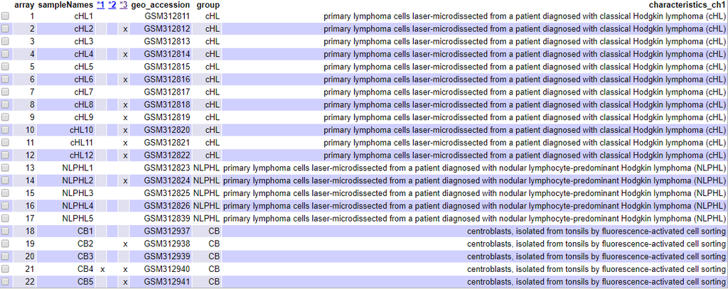

Salvo CB4 todos los archivos parece correctos, sobre todo fallan en el MA plot que es un indicador de la calidad individual del array, esto puede indicar que los arrays tienen diferentes intensidades de fondo o por saturación de la señal, se recomienda consultar la seccion 4 del informe “Individual array quality” para más información.

Para verlo mejor voy a hacer un análisis de componentes principales

```r
tabla <- exprs(raw)

# escalar los datos es recomendable cuando no quieres que tengan más peso las variables con valores altos que las varaibles con valores bajos, como es este caso.
PCA <- prcomp(t(tabla), scale=T)
PCs <- data.frame(PCA$x)

# varianza explicada por cada componente
summary(PCA)$importance
```

```
                              PC1       PC2       PC3       PC4       PC5       PC6       PC7       PC8       PC9      PC10
Standard deviation     1001.56186 305.21094 213.99127 190.53046 182.08173 171.60025 147.51852 144.94596 123.99134 106.07305
Proportion of Variance    0.74037   0.06875   0.03380   0.02679   0.02447   0.02173   0.01606   0.01551   0.01135   0.00830
Cumulative Proportion     0.74037   0.80912   0.84292   0.86972   0.89419   0.91592   0.93198   0.94749   0.95883   0.96714
                           PC11     PC12     PC13     PC14     PC15     PC16     PC17     PC18     PC19     PC20     PC21
Standard deviation     84.59389 74.25152 68.29560 67.94841 64.43757 63.37154 59.12445 56.04185 52.33296 52.03428 48.20446
Proportion of Variance  0.00528  0.00407  0.00344  0.00341  0.00306  0.00296  0.00258  0.00232  0.00202  0.00200  0.00172
Cumulative Proportion   0.97242  0.97649  0.97993  0.98334  0.98640  0.98937  0.99195  0.99427  0.99629  0.99828  1.00000
                               PC22
Standard deviation     9.067596e-12
Proportion of Variance 0.000000e+00
Cumulative Proportion  1.000000e+00
```

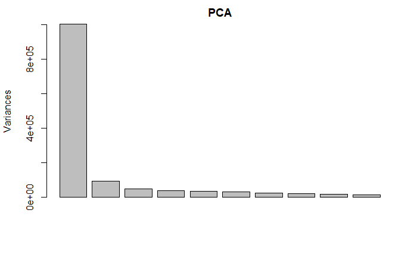

```r
screeplot(PCA)
```

```r
# con dos componentes se explica el 80% de la varianza, suficiente para hacernos una buena idea de como se distribuyen los patrones de expresión y una tercera dimensión apenas aporta nada, por tanto voy a representarlo en 2D.
pc1<-round(summary(PCA)$importance[2,1]*100,1)
pc2<-round(summary(PCA)$importance[2,2]*100,1)
# pc3<-round(summary(PCA)$importance[2,3]*100,1)
```

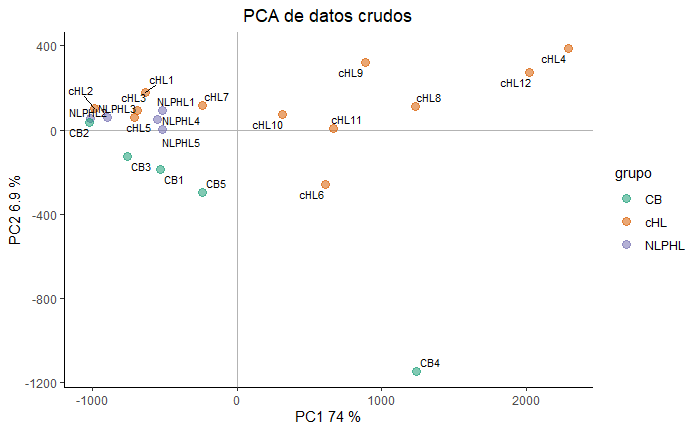

```r
grupo <- pData(raw)$group
etiqueta <- pData(raw)$title

# main plot
ggplot(PCs,aes(x=PC1, y=PC2)) +
  theme_classic() +
  geom_hline(yintercept = 0, color = "gray70") +
  geom_vline(xintercept = 0, color = "gray70") +
  geom_point(aes(color = grupo), alpha = 0.55, size = 3) +
  coord_cartesian(xlim = c(min(PCA$x[,1])-5,max(PCA$x[,1])+5)) +
  geom_text_repel(aes(y = PC2 + 0.25, label = etiqueta),segment.size = 0.25, size = 3) +
  labs(x = c(paste("PC1",pc1,"%")),y=c(paste("PC2",pc2,"%"))) +
  ggtitle("PCA de datos crudos")+
  theme(plot.title = element_text(hjust = 0.5)) +
  # pongo colores fácilmente distinguibles por daltónicos
  scale_color_manual(values= c("#1b9e77", "#d95f02", "#7570b3"))
```

El PCA nos muestra lo mismo que el análisis previo, CB4 muestra un patrón muy diferente a las otras células, quizás la normalización arregle estas diferencias, voy a probar a normalizar con y sin CB4 y me quedaré con lo que mejores resultados me de.

# Normalización

Se hace para poder comparar entre arrays, reduciendo el error entre muestras. Requiere 3 pasos, corregir ruido de fondo (background), normalizar y sumarizar. Normalmente se normaliza con rma (Robust Multichip Analysis).

```r
normalizados <- rma(raw) # devuelve las cuentas normalizadas como ExpressionSet
```

```
Background correcting
Normalizing
Calculating Expression
```

```r
write.csv(exprs(normalizados), file="./00 Resultados/datos normalizados.csv")
save(normalizados, file="archivos intermedios/normalizados.Rdata")
```

aqui al final puedo poner un antes y después, esto es el antes de la normalizacion

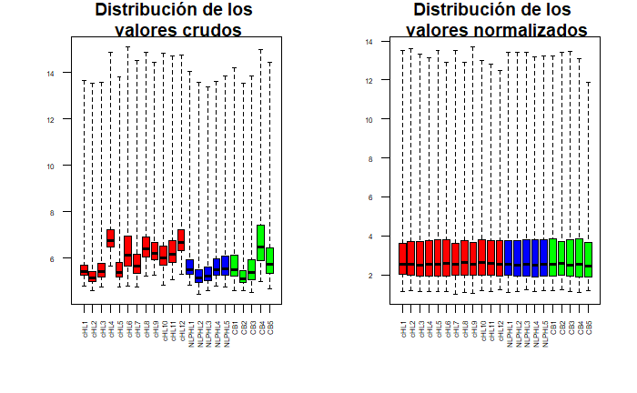

```r
par(mfrow = c(1,2))
boxplot(raw, cex.axis=0.5, las=2,
         col = c(rep("red", 12), rep("blue", 5), rep("green", 5)),
         main="Distribución de los \n valores crudos")

boxplot(normalizados, cex.axis=0.5, las=2,
         col = c(rep("red", 12), rep("blue", 5), rep("green", 5)),
         main="Distribución de los \n valores normalizados")
```